# Predicting Tuition Costs

Shaun Sandbloom - srs341@georgetown.edu

12/16/2021

## Introduction

- The student debt crisis is a frequent topic of discussion in policy environments.
- There are a wide variety of factors that contribute to the problem.
- But debt starts with one key factor - **cost**.

#### Meaning of Education

- “Education” can mean something different to everyone.
- Formal, structured post-secondary education occurs in a variety of formats.
- What appears to stand out is what it takes to earn a **bachelor’s degree** from a **four-year academic program** commonly offered by universities.
- This analysis explores the characteristics of both **public** and **private (non-profit)** universities that award bachelor’s degrees for completing a **four-year** academic program.

## Data Source

#### [The U.S. Department of Education College Scorecard API](https://collegescorecard.ed.gov/data/documentation/)

- Data documentation can be found [here](https://collegescorecard.ed.gov/data/documentation/)
- The API data dictionary can be found [here](https://collegescorecard.ed.gov/assets/FullDataDocumentation.pdf)

## Extraction, Transformation, and Loading (ETL)

The College Scorecard API uses a parameter-based query structure. Additionally, the API will only return 100 rows of data at a time. This means queries with large-volume requests will need to be iterated over multiple requests and aggregated into a larger data frame.

To simplify queries to the API, I first created a user-defined function to format the desired attributes appropriately for the request URL.

```r
query_scorecard <- function(endpoint, filters, fields, per_page, page){
  api_path <- "https://api.data.gov/ed/collegescorecard/v1/"
  query <- paste0(
    api_path,
    endpoint,
    ".json?",
    filters,
    "&fields=",
    paste(fields, collapse = ","),
    "&per_page=",
    per_page,
    "&page=",
    page,
    "&api_key=",
    api_key
    )
  print(query)
  print("Querying...")
  response <- GET(query)
  if(http_error(response)) {
    print("Query failed.")
    print(http_status(response)$message)
  } else {
    print("Query confirmed.")
    print(paste("Data type:", http_type(response)))

    content <- content(response, as = "text")
    results <- fromJSON(content)
    final <- tibble(results$results)
  }
}
```

#### Variables collected

The following data points are the result of pulling data from the **College Scorecard API** from 2000-2019 and extensive transformation. The Department of Education publishes an [Excel spreadsheet](https://collegescorecard.ed.gov/assets/CollegeScorecardDataDictionary.xlsx) with over 2000 variables on academic institutions.

| Variable | Description |
| --- | --- |
| `id` | A school’s IPED code |
| `name` | A school’s name |
| `city` | The city the school is located |
| `state` | The state the school is located |
| `ownership` | A value denoting if a school is public or private non-profit |
| `tuition_type` | Distinguishes between in-state and out-of-state rates |
| `tuition_rate` | The financial cost of tuition for an academic and/or program year |
| `location.lat` | A school’s latitudinal coordinate |
| `location.lon` | A school’s longitudinal coordinate |
| `size` | Categorical description of the the school’s size |
| `size_details` | Categorical description of the student body |
| `locale_type` | Categorical description of the school’s geographic setting |
| `locale_size` | Categorical description of the size of the geographical setting |

## Exploratory Data Analysis (EDA)

#### How have tuition rates evolved over the last 20 years?

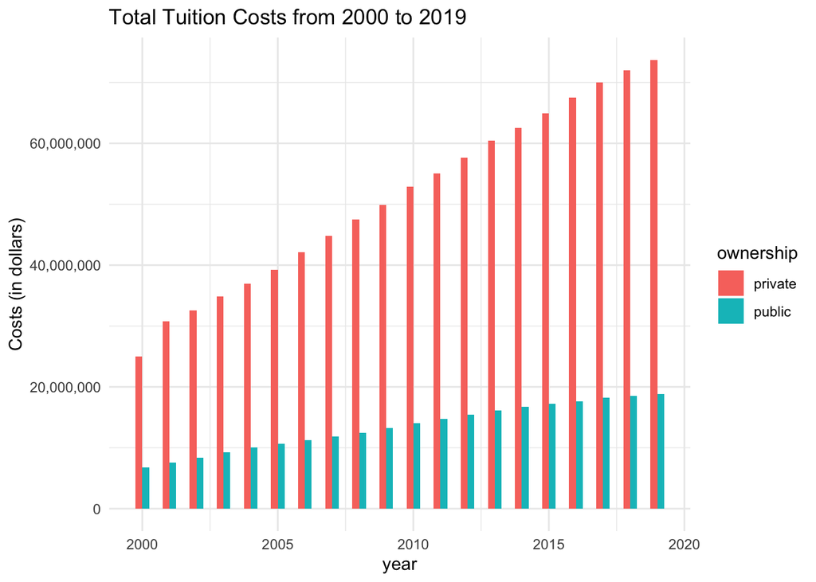

#### What’s meaningful about this view

- Annual tuition costs appear to be steadily rising across both public and private institutions.
- As a whole, the cost of private higher-education appears to be significantly more expensive.

#### What this view doesn’t answer

- Calculating total costs on an annual basis overlooks the number of schools in each category…
- Are there simply more private schools than public schools?

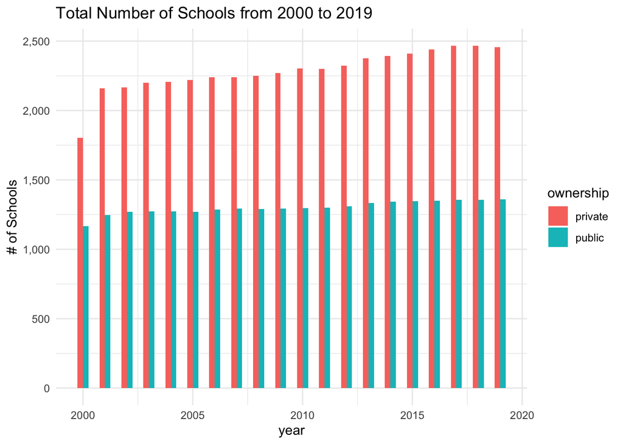

#### Comparing tution rates from state-to-state

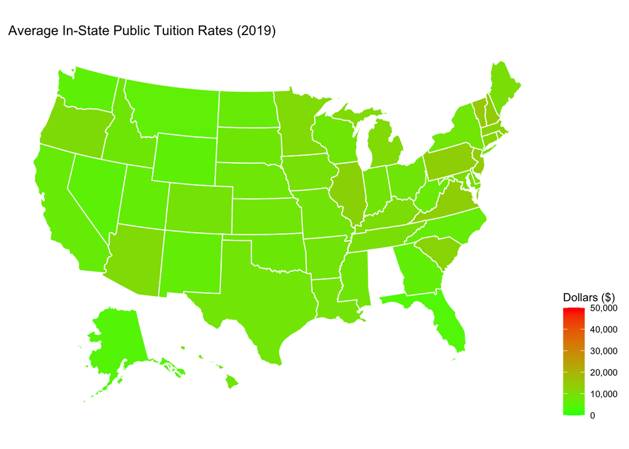

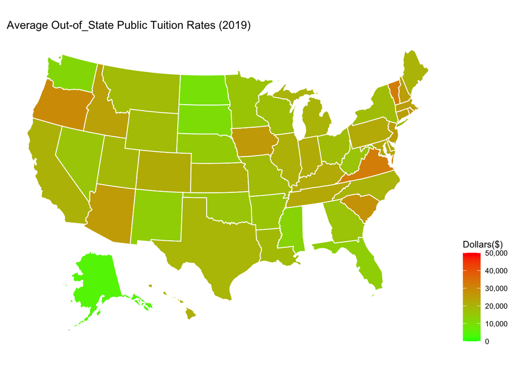

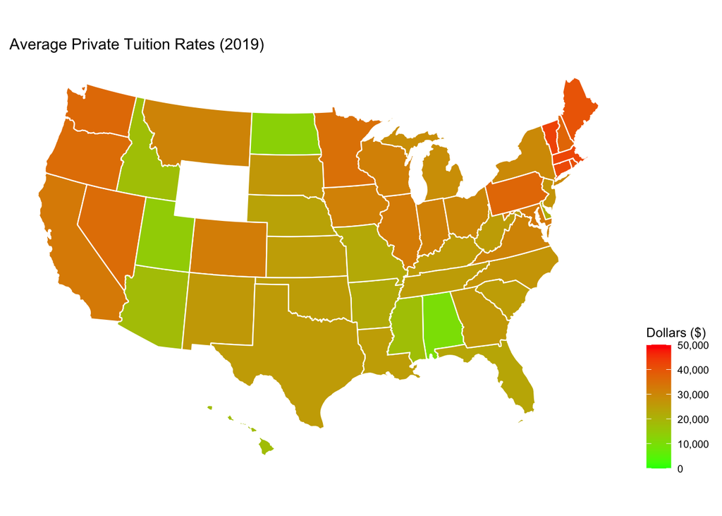

#### Wanna get away?

- There’s a clear financial advantage to attending a four-year public institution in your home state.
- Students who choose to attend an out-of-state public institution might consider nearby private alternatives, **depending on the state**.

### One last exploration into the evolution to tuition costs…

#### Most Expensive and Least Expensive Schools: 2019

| name | city | state | ownership | cost |
| --- | --- | --- | --- | --- |
| Columbia University in the City of New York | New York | NY | private | 61788 |
| University of Chicago | Chicago | IL | private | 60552 |
| Jewish Theological Seminary of America | New York | NY | private | 59112 |
| Landmark College | Putney | VT | private | 59100 |
| Trinity College | Hartford | CT | private | 59050 |
| Franklin and Marshall College | Lancaster | PA | private | 58800 |

| name | city | state | ownership | cost |
| --- | --- | --- | --- | --- |
| Grace Mission University | Fullerton | CA | private | 3120 |
| Curtis Institute of Music | Philadelphia | PA | private | 2900 |
| Oglala Lakota College | Kyle | SD | public | 2684 |
| Stone Child College | Box Elder | MT | public | 2645 |
| Turtle Mountain Community College | Belcourt | ND | private | 2250 |
| United States Merchant Marine Academy | Kings Point | NY | public | 1050 |

#### Most Expensive and Least Expensive Schools: 2000

| name | city | state | ownership | cost |
| --- | --- | --- | --- | --- |
| Colby College | Waterville | ME | private | 32750 |
| Connecticut College | New London | CT | private | 31985 |
| Landmark College | Putney | VT | private | 30500 |
| Sarah Lawrence College | Bronxville | NY | private | 26668 |
| Wesleyan University | Middletown | CT | private | 26180 |
| Hamilton College | Clinton | NY | private | 26100 |

| name | city | state | ownership | cost |
| --- | --- | --- | --- | --- |
| Sinte Gleska University | Mission | SD | public | 1632 |
| Midland College | Midland | TX | public | 1598 |
| Tyler Junior College | Tyler | TX | public | 1580 |
| Northern New Mexico College | Espanola | NM | public | 1546 |
| Turtle Mountain Community College | Belcourt | ND | private | 1536 |
| Moody Bible Institute | Chicago | IL | private | 1225 |

## Continuing the discussion…

Future analyses may offer new insights on these data, by exploring predictive models and evaluating which of the variables above have a significant impact on predicting future tuition costs.